# Bullying Network

Aurora Maria Tumminello, Lucia Hrovatin

# Importing data

## Data Structure

The original dataset `bullying_network.xlsx` is an Excel file that contains two sheets about bullying within a group of 25 students in an Italian school class: the first one encloses three attributes per student; the second one represents the adjacency matrix of a directed network depicting who bullies whom among the students.

The first sheet, the attributes one, contains:

- **gender**, mapped in females (0) and males (1);
- **grade**, which goes from 0 to 10;
- **ethnicity**, divided into three categories: first-generation immigrants (born abroad with foreign parents), second-generation immigrants (born in Italy with foreign parents) and Italians (born in Italy with at least one Italian parent).

## Data pre-processing

As forehead described, the original Excel file contains two sheets. To retrieve information there stored, a first approach exploited the `read_excel(path, sheet)` function and saved the two sheets in different variables. Since this attempt implied a network misreading of 0s and 1s as characters instead of double and creating an undirected graph, we opted for another importing action: the original Excel file has been separated manually into two different csv files:

- `bullying_attributes.csv`: containing the attributes of students inside the network;
- `bullying_network.csv`: containing the actual adjacency matrix (i.e. the network).

## Libraries

```r
library(tidyverse)
library(sna)
library(knitr)
library(itsadug) # For gradient legend
library(formattable) # For nice tables
library(igraph)
library(visNetwork)
```

## Data import

### Import network data

With the following code, the network is imported, converted into matrix and then into directed network.

```r
# Importing data
net = as.matrix(read.csv("bullying_network.csv",
                         stringsAsFactors=FALSE, row.names=1))
# Converting the adjacency matrix to a network
net = as.network(net, directed=T)
# Inspect the network
summary(net, print.adj = FALSE)
```

```
Network attributes:
  vertices = 25
  directed = TRUE
  hyper = FALSE
  loops = FALSE
  multiple = FALSE
  bipartite = FALSE
 total edges = 76
   missing edges = 0
   non-missing edges = 76
 density = 0.1266667

Vertex attributes:
  vertex.names:
   character valued attribute
   25 valid vertex names

No edge attributes
```

By inspecting the obtained network through `summary(net)`, we may notice:

- the number of vertices (i.e., nodes), which are 25 students;
- that the network is directed;
- that no hyperedges, loops or multiple edges are allowed;
- that there are overall 76 directed edges;
- that the density is 0.127;
- that nodes are labeled with names, namely the students’ first names.

### Import attributes

Students attributes have been saved in a distinct file and, therefore, imported separately.

```r
# Reading the csv file with node attributes with given types for summary
attr = read.csv("bullying_attributes.csv",
                colClasses = c("character","factor","numeric","factor"))
summary(attr)
```

```
      ID            Gender     Grade       Ethnicity
 Length:25          0:12   Min.   : 3.00   1: 5
 Class :character   1:13   1st Qu.: 5.00   2: 6
 Mode  :character          Median : 6.00   3:14
                           Mean   : 6.16
                           3rd Qu.: 8.00
                           Max.   :10.00
```

As can be seen from the summary, there are more males than females, but this distinction is not significant since the class has an odd number of students. Instead, ethnicity registers a more significant difference, showing 11 immigrants and 14 Italians. The minimum grade is 3, although marks start typically from 0, while the maximum is 10. Both median and mean of the class are around 6, which corresponds to the sufficiency in the Italian system.

```r
# Re-importing as numerical for the following plots and measures
attr = read.csv("bullying_attributes.csv")
```

# Drawing a network

## Basic Draw

💡 *Draw the network using the Fruchterman-Reingold layout with names (but without attributes).*

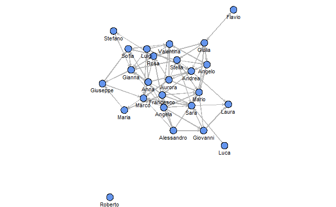

```r
par(mar=c(0,0,0,0)) # Margin deletion
gplot(net,
      gmode="digraph",    # directed network
      mode="fruchtermanreingold", # set mode as Fruchterman-Reingold
      jitter=F,           # do not allow nodes to be "jittered"
      edge.col="grey70",  # set color of ties
      vertex.col="cornflowerblue",   # set color of nodes
      vertex.sides = 100,
      displaylabels=T,    # indicate that labels should be included
      label.pos=1,        # indicate that labels should be given below points
      label.cex=.7,       # indicate the size of the labels (1 is default)
      arrowhead.cex = 0.4)
```

The *Fruchterman-Reingold* layout is the default mode of the `gplot()` function, and therefore it is not necessary to include it. Overall there are 25 labelled nodes connected through directed links representing who bullies whom. In particular, there is a student, Roberto, that does not present incoming or outgoing edges and, following the definition of Wasserman & Faust (1994), it is an **isolate**[^1]. Therefore, Roberto is the only student in this specific school class that is not bullied and does not bully either.

## Attribute-based network

💡 *Next, draw the network again using the Fruchterman-Reingold layout without names, but now with all 3 attributes (gender, grade and ethnicity) included using in some way a combination of colour, shape and size of nodes.*

💡 *Create a legend for the attributes (this does not have to be with R, but needs to clarify how the different attributes were represented in the network).*

Once again, let’s consider the three attributes and their respective values:

- **Gender**: binomial variable 0/1;
- **Ethnicity**: categorical variable assuming three different values (1, 2 or 3);
- **Grade**: categorical variable assuming 11 different values (from 0 to 10).

These three attributes are all **categorical** data and, specifically, can be divided into **nominal** (gender and ethnicity) and **ordinal** (grade). This distinction implies a further difference in the visualisation. Whereas the nominal values can be mapped using variation in colour hue or shape, the ordinal ones may lead to different conclusions. Below two versions are displayed, using a combination of shape, colour and size. The first one variates the datum size (area) and fits data based on proportional scales where the larger sizes mean greater quantities (e.g., grade 10). The second option exploits the colours’ lightness. Thus, lightness variation can represent quantitative scales, where the darker the colour, the greater the quantity[^2].

### First version

A first version considers the variations in:

- **size** as grade;
- **shape** as gender;
- **colour** as ethnicity.

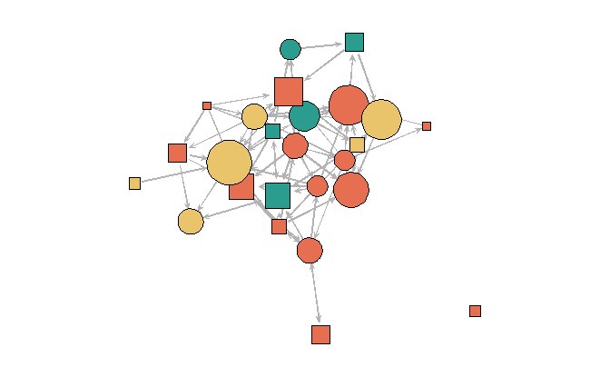

```r
colours_1 = c("#2a9d8f", "#e9c46a", "#e76f51")
sizes = seq(0.1, 4, length.out=11)

par(mar=c(0,0,0,0))
gplot(net,
      gmode="digraph",    # directed network
      jitter=T,
      edge.col="grey70",  # set color of ties
      vertex.col=colours_1[attr$Ethnicity], # set color of nodes depending on ethnicity
      vertex.cex = sizes[attr$Grade], # set size of nodes depending on grade
      vertex.sides= (attr$Gender-1)*47+4, # set shape of nodes depending on gender
            vertex.rot = 45, # Nodes rotation
      arrowhead.cex = 0.5) # Size of the arrows head
```

In this representation, both gender and ethnicity are evident, while the size does not accurately represent the grade. Moreover, to visualize the grade, a size vector proportionally maps the node’s size to its grade. Although this combination satisfies the assigned requirements, the user might experience difficulties distinguishing the grades differences.

In the following chunk, a legend is added to guide the user in the reading of the network:

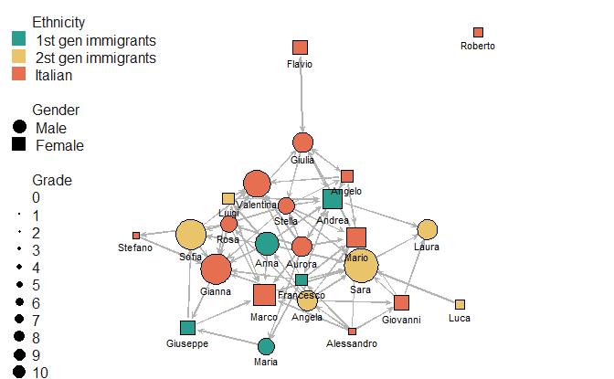

```r
sizes = seq(0.2, 3, length.out=11)

par(mar=c(0,0,0,0)) # Margin deletion
gplot(net,
      gmode="digraph",    # directed network
      jitter=T,
      edge.col="grey70",  # set color of ties
      vertex.col=colours_1[attr$Ethnicity],   # set color of nodes depending on ethnicity
      vertex.cex = sizes[attr$Grade], # set size of nodes depending on grade
      vertex.sides= (attr$Gender-1)*47+4, # set shape of nodes depending on gender
      vertex.rot = 45,
      arrowhead.cex = 0.5,
      displaylabels=T,    # indicate that labels should be included
      label.pos=1,        # indicate that labels should be given below points
      label.cex=.7)       # indicate the size of the labels (1 is default)

legend("topleft",
       legend = c("Ethnicity"," 1st gen immigrants", " 2st gen immigrants", " Italian",
                  " ", "Gender", " Male", " Female",
                  " ", "Grade", 0:10),
       col = c("white",colours_1[1],colours_1[2],colours_1[3],
               "white","white","black","black",
               "white", "white", rep("black",11)),
       bty = "n",
       pch =c(15,15,15,15,
              15,15,19,15,
              15,15,rep(19,11)),
       pt.cex = c(0,2.1,2.1, 2.1,
                  0,0,2.1,2.1,
                  0, 0, (0:10)/5),
       cex = 1,
       text.col = "grey10",
       horiz = F ,
       inset = c(0.01))
```

### Second version

As stated above, the second approach represents the attributes in a different way:

- **shape**: ethnicity (i.e., first-generation as triangles, second-generation as squares and Italians as circles);
- **colour hue**: gender (i.e., females as red, males as green);
- **colour lightness**: grade (the darker the higher, the lighter the lower).

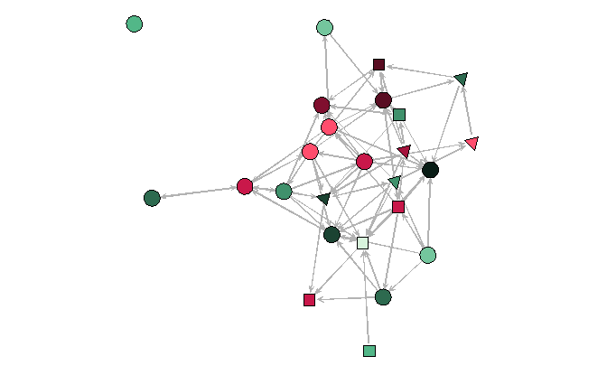

```r
colours_2 = c('#fff0f3', '#ffccd5', '#ffb3c1', '#ff8fa3', '#ff758f', # Reds
              '#ff4d6d', '#c9184a', '#a4133c', '#800f2f', '#590d22', # Reds
              "#d8f3dc","#b7e4c7","#95d5b2","#74c69d","#52b788",     # Greens
              "#40916c", "#2d6a4f","#245741","#1b4332","#081c15"     # Greens
)

shapes = c(3,4,50)

par(mar=c(0,0,0,0)) # Margin deletion
gplot(net,
      gmode="digraph",    # directed network
      jitter=F,           # do not allow nodes to be "jittered"
      edge.col="grey70",  # set color of ties
      vertex.col=colours_2[attr$Gender*10+attr$Grade+1],   # set color of nodes
      vertex.cex = 1.3,
      vertex.rot = 45,
      vertex.sides= shapes[attr$Ethnicity],
      arrowhead.cex = 0.5)
```

Despite ethnicity losing evidence, the grade variable acquires a central role in this visualisation. Thus, the use of colour lightness to highlight the grades (i.e. higher grades with darker colours) emphasizes the differences more than in the previous case where size was employed.

Notice that the exercise also required the use of **size**. However, applying size variation to gender or ethnicity may unconsciously suggest a social superiority of one of the two categories, which does not exist. Thus, this visualisation does not consider the size to avoid any possible misunderstanding.

In this case, the legend shows:

- ethnicity as shapes;
- gender as one of the two colours;
- grade as a gradient, varying between males and females, whose lightness relies on the students’ grade.

This solution may help understand the grade distribution among students, but getting the exact grade is still challenging.

```r
par(mar=c(0,0,0,0)) # Margin deletion
gplot(net,
      gmode="digraph",    # directed network
      jitter=T,           # do not allow nodes to be "jittered"
      edge.col="grey70",  # set color of ties
      vertex.col=colours_2[attr$Gender*10+attr$Grade+1],   # set color of nodes
      vertex.cex = 1,
      vertex.rot = 45,
      vertex.sides= shapes[attr$Ethnicity],
      displaylabels=T,    # indicate that labels should be included
      arrowhead.cex = 0.5,
      label.pos=1,        # indicate that labels should be given below points
      label.cex=.7)       # indicate the size of the labels (1 is default))

# Legend for gender and ethnicity
legend("topleft",
       legend = c("Ethnicity"," 1st gen immigrants", " 2st gen immigrants", " Italian",
                  " ", "Gender", " Male", " Female",
                  " ", "Grade"),
       col = c("white","black","black", "black",
               "white","white","#52b788","#ff4d6d",
               "white", "white"),
       bty = "n",
       pch =c(15,17,15,19,
              15,15,15,15,
              15, 15),
       pt.cex = c(0,2.1,2.1, 2.2,
                  0,0,2.1,2.1,
                  0,0),
       cex = 1,
       text.col = "grey10",
       horiz = F ,
       inset = c(0.01))
```

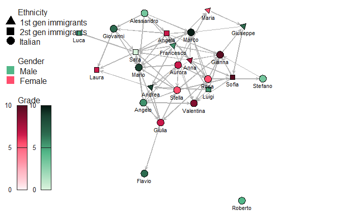

```r
# Gradient legend
pal = colorRampPalette(colours_2[1:10])
gradientLegend(valRange=c(0,10),
               color = pal(10),
               pos=c(0.05,0.1,.08,0.5),
               side=4,
               n.seg=1,
               border.col = "grey10",
               inside = T)

pal = colorRampPalette(colours_2[11:20])
gradientLegend(valRange=c(0,10),
               color = pal(10),
               pos=c(0.12,0.1,.15,0.5), side=4,
               n.seg=1,
               border.col = "grey10",
               inside = T)
```

### Third interactive version

This third version exploits the package `visNetwork` to build an interactive visualisation of the network, reproducing the first version forehead proposed, where:

- shapes indicate the gender (i.e. females as circles, males as squares);
- colour hue indicates the ethnicity, as shown in the legend;
- the size is handled based on the grade of the single student.

Moreover, ethnicity can be chosen through the selection above the plot.

```r
# Creation of the igraph network
i_net<-graph_from_adjacency_matrix(as.matrix(read.csv("bullying_network.csv",
                                                      row.names = 1,
                                                      stringsAsFactors = F)),
                                   mode="directed", diag=F)

# Setting colours, shapes, sizes, ethnicity, gender, title
V(i_net)$color = colours_1[attr$Ethnicity]
V(i_net)$shape = c("dot","square")[attr$Gender+1]
V(i_net)$size = attr$Grade*3
V(i_net)$ethnicity = ifelse(attr$Ethnicity==3, "Italian",
                            ifelse(attr$Ethnicity == 1,"1st immigrant", "2nd immigrant"))
V(i_net)$gender = ifelse(attr$Gender == 0, "Female","Male")
V(i_net)$title = paste0("<p><b>", attr$ID,"</b><br>",
                        V(i_net)$gender,", ",attr$Grade,", ",
                        V(i_net)$ethnicity,"</p>")

# Dataframe for the legend
lnodes <- data.frame(label = c("1st immigrants","2nd immigrants","Italians","Females", "Males"),
                     shape = c(rep("triangle",3),"dot","square"),
                     color = c(colours_1,"#B78FB5","#B78FB5"),
                     font.size = 10,
                     title = "Informations")

# Creation of the visNetwork object
new_net = toVisNetworkData(i_net)

# Actual visualisation
visNetwork(nodes = new_net$nodes,
           edges = new_net$edges,
           height = "800px", width = "100%",
           font.size = 9,
           physics = T) %>%
    visEdges(arrows = "to") %>%
    visOptions(highlightNearest = TRUE,
               selectedBy = "ethnicity") %>%
    visIgraphLayout(layout = "layout.fruchterman.reingold") %>%
    visLegend(addNodes = lnodes, useGroups = FALSE, ncol = 1)
```

[interactive chart not shown]

The interactive version offers better exploitation and comprehension of the network through the possibility of visualising all the information related to a node by just clicking on it. By introducing a further layer, the problem of grades definition and comparison is solved.

# Centrality

💡 *Calculate in and out-degree centrality for each node and interpret the results.*

**Degree centrality** is defined as the number of links incident upon a node. Having a directed network implies splitting the degree into in-degree and out-degree. The former counts the number of incoming edges to a node, while the latter refers to the number of edges a node directs to others[^3].

When edges express positive aspects (e.g., friendship, collaboration), in-degree can be interpreted as a form of popularity and out-degree as gregariousness. However, a reversed scenario is presented here due to the edges’ negative connotation, i.e. bullying.

## In-degree

💡 *Who is the most central when it comes to in-degree?*

💡 *Provide details of the meaning of the value (taking into account that the network is “who do you bully?”).*

💡 *Make sure to discuss the reference points for the in-degree measure. How does it compare to the theoretical minimum and maximum value?*

Let’s first consider the in-degree centrality of nodes with the function `degree(network, gmode, cmode="indegree")`, which will return the in-degree for each student. The same function can be used to compute the out-degree, setting `cmode="outdegree"`.

```r
# How many people are you bullied from?
indegree = sna::degree(net, gmode="digraph", cmode = "indegree")

# How many people do you bully?
outdegree = sna::degree(net, gmode="digraph", cmode = "outdegree")

# Overall Degree
degree = sna::degree(net, gmode="digraph")

attr$indegree = indegree
attr$outdegree = outdegree
```

To properly present the degree centrality measures, a dataframe has been created with students names, in-degree, out-degree and total degree (i.e. the sum of both in and out-degree). In addition, the normalized in-degree is computed by dividing the in-degree over the number of nodes minus $1$ (i.e. $n-1$). The last column indicates whether the single node in-degree is below (or above) the average.

| Name | In degree | Out degree | Degree | Normalized In degree | Above Average (In degree) |
| --- | --- | --- | --- | --- | --- |
| Sara | 9 | 2 | 11 | 0.38 |  |
| Gianna | 8 | 1 | 9 | 0.33 |  |
| Marco | 8 | 1 | 9 | 0.33 |  |
| Andrea | 7 | 2 | 9 | 0.29 |  |
| Mario | 7 | 2 | 9 | 0.29 |  |
| Valentina | 6 | 0 | 6 | 0.25 |  |
| Giulia | 4 | 4 | 8 | 0.17 |  |
| Laura | 3 | 0 | 3 | 0.12 |  |
| Sofia | 3 | 2 | 5 | 0.12 |  |
| Angela | 2 | 7 | 9 | 0.08 |  |
| Angelo | 2 | 6 | 8 | 0.08 |  |
| Francesco | 2 | 7 | 9 | 0.08 |  |
| Giovanni | 2 | 3 | 5 | 0.08 |  |
| Giuseppe | 2 | 2 | 4 | 0.08 |  |
| Maria | 2 | 1 | 3 | 0.08 |  |
| Rosa | 2 | 5 | 7 | 0.08 |  |
| Stella | 2 | 6 | 8 | 0.08 |  |
| Anna | 1 | 6 | 7 | 0.04 |  |
| Aurora | 1 | 7 | 8 | 0.04 |  |
| Flavio | 1 | 1 | 2 | 0.04 |  |
| Luigi | 1 | 4 | 5 | 0.04 |  |
| Stefano | 1 | 1 | 2 | 0.04 |  |
| Alessandro | 0 | 5 | 5 | 0.00 |  |
| Luca | 0 | 1 | 1 | 0.00 |  |
| Roberto | 0 | 0 | 0 | 0.00 |  |

By considering the in-degree centrality, Sara can be defined as the most central node, followed by Gianna and Marco. As stated above, whereas having many incoming edges represents an advantageous condition for the individual in several cases, this specific network emphasizes an unfavourable status. Thus, in-degree measure refers to the number of bullies a node must face. Consequently, Sara results the chosen victim and gets bullied by $9$ people, which corresponds to the $0.375\%$ of the network (normalization obtained by $\frac{in-degree}{n-1} = \frac{9}{24} = 0.375$, with $n$ number of nodes).

In the worst-case scenario, Sara would be bullied by $24$ students, and she would be the only victim. However, despite her seeming far from the depicted scenario, her in-degree looks exceptionally high considering the average and the median in-degree. The same happens for students like Gianna, Marco, Andrea, Mario, Valentina and Giulia.

It is also worth noticing that Sara’s condition seems not to be determined by her ethnicity or gender, but by her grade. While at least one member per ethnicity and/or per gender has been bullied, the reason for which Sara is bullied by several students might be the achievement of the highest mark: $10$.

| Measures | Value |
| --- | --- |
| Most central node | Sara |
| Max in degree | 9 |
| (Theoretical) max in degree | 24 |
| Least central nodes | Alessandro, Luca, Roberto |
| Min in degree | 0 |
| (Theoretical) min in degree | 0 |
| Average in degree | 3.04 |
| Median in degree | 2 |

As the bar plot below shows, the average is strongly impacted by the unbalanced situation within the network, meaning a group of highly bullied victims against the remaining nodes assessing low in-degree values. The extreme cases ($in-degree = 0$) are further analysed in the following sections and might reflect either isolate (i.e. Roberto) or bully figures.

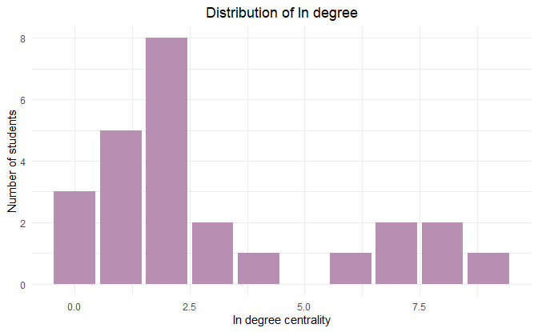

[interactive chart not shown]

## Outdegree

💡 *Who is the most central when it comes to out degree?*

💡 *Provide details of the meaning of the value (taking into account that the network is “who do you bully?”).*

💡 *Make sure to discuss the reference points for the outdegree measure. How does it compare to the theoretical minimum and maximum value?*

There is no unique central node in the case of the out-degree measure. Thus, Angela, Aurora, and Francesco can be detected as the $3$ most central nodes (as shown in the table below). It is also worth noticing that their degree measure is assessed at $9$ and $8$ and, therefore, they are not the extreme cases hypothesized above (i.e., $in-degree=0$). As already performed in the in-degree case, some reference points are computed and reported below.

| Name | Out degree | In degree | Degree | Normalized Out degree | Above Average (Out degree) |
| --- | --- | --- | --- | --- | --- |
| Angela | 7 | 2 | 9 | 0.292 |  |
| Aurora | 7 | 1 | 8 | 0.292 |  |
| Francesco | 7 | 2 | 9 | 0.292 |  |
| Angelo | 6 | 2 | 8 | 0.250 |  |
| Anna | 6 | 1 | 7 | 0.250 |  |
| Stella | 6 | 2 | 8 | 0.250 |  |
| Alessandro | 5 | 0 | 5 | 0.208 |  |
| Rosa | 5 | 2 | 7 | 0.208 |  |
| Giulia | 4 | 4 | 8 | 0.167 |  |
| Luigi | 4 | 1 | 5 | 0.167 |  |
| Giovanni | 3 | 2 | 5 | 0.125 |  |
| Andrea | 2 | 7 | 9 | 0.083 |  |
| Giuseppe | 2 | 2 | 4 | 0.083 |  |
| Mario | 2 | 7 | 9 | 0.083 |  |
| Sara | 2 | 9 | 11 | 0.083 |  |
| Sofia | 2 | 3 | 5 | 0.083 |  |
| Flavio | 1 | 1 | 2 | 0.042 |  |
| Gianna | 1 | 8 | 9 | 0.042 |  |
| Luca | 1 | 0 | 1 | 0.042 |  |
| Marco | 1 | 8 | 9 | 0.042 |  |
| Maria | 1 | 2 | 3 | 0.042 |  |
| Stefano | 1 | 1 | 2 | 0.042 |  |
| Laura | 0 | 3 | 3 | 0.000 |  |
| Roberto | 0 | 0 | 0 | 0.000 |  |
| Valentina | 0 | 6 | 6 | 0.000 |  |

| Measures | Value |
| --- | --- |
| Most central node | Angela, Aurora, Francesco |
| Max out degree | 7 |
| (Theoretical) max out degree | 24 |
| Least central nodes | Laura, Roberto, Valentina |
| Min out degree | 0 |
| (Theoretical) min out degree | 0 |
| Average out degree | 3.04 |
| Median out degree | 2 |

Each of the three central out-degree nodes bullies almost one-third of the overall network:

$$\left[ \frac{outdegree}{n-1} = \frac{7}{24} = 0.291 \approx 0.29 \approx \frac{1}{3}\right]$$

These values are highly above the average of 3.04 $\pm$ 2.423 but do not reach extreme cases, such as in a completely centralized network (i.e. maximum out-degree). Moreover, a visual interpretation of the out-degree distribution in a bar plot graph may help understand the underlying reasons for the low reference points.

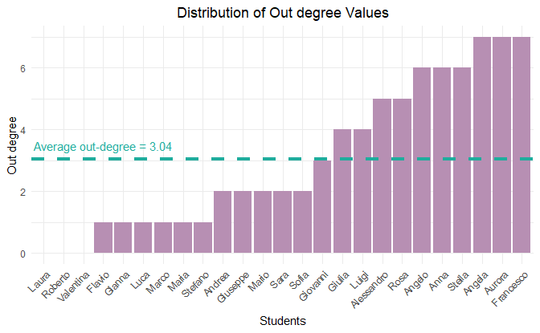

Once again, the out-degree measure shows an imbalanced situation assessing a significant gap between the lowest extreme cases (e.g. $0$) and the highest ones (i.e.,$7$). Overall, $15$ nodes have an out-degree below average, while the remaining $10$ nodes score slightly above average or double it in the most central nodes.

[interactive chart not shown]

## Correlations

💡 *Let’s assume we hypothesize that the grade of students might be impacted by how many others they are being bullied by. Calculate the correlation between the in-degree and the grade of the kid.*

- *What is the correlation value?*
- *What does it mean substantively?*

### Grade and in-degree

```r
grade = attr$Grade
cor_value = cor(indegree, grade, method = c("pearson"))
cor_value
```

```
[1] 0.852993
```

```r
cor.test(indegree,grade)
```

```
    Pearson's product-moment correlation

data:  indegree and grade
t = 7.838, df = 23, p-value = 6.082e-08
alternative hypothesis: true correlation is not equal to 0
95 percent confidence interval:
 0.6906372 0.9334951
sample estimates:
     cor
0.852993
```

Moreover, the correlation test shows a low p-value, indicating a statistically significant relationship between the number of people that bully and the grade they get, illustrated by the following scatter plot. In particular, each data point is described in terms of grade (y-axis) and in-degree (x-axis). The linear relationship between these variables is reported along with its $95%$ confidence interval.

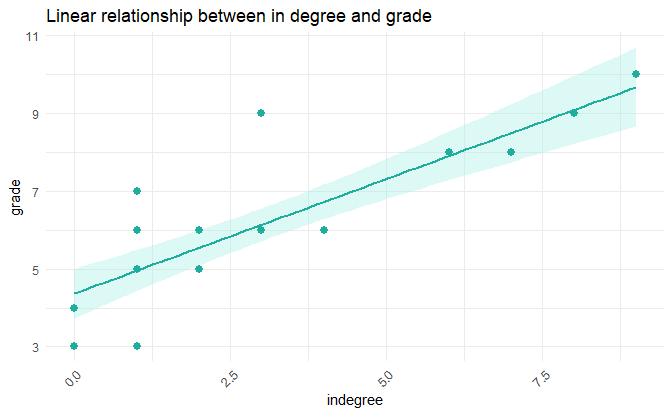

However, despite the high correlation coefficient, it is worth noticing some fallacies in the model:

1. Low number of students: since our sample has a small number of subjects, this model is not representative for the entire school system bullying mechanism;
2. The line fits the majority of points. Nevertheless, some outliers can be detected from the plot (e.g. point at coordinates $p=(3,9)$).

For confirming the relationship between grade and being bullied, the ANOVA test is applied, showing a low p-value and therefore a discriminant factor for the studied network. In particular, the pairwise test displays pairs of grades where there is a substantial difference in terms of being bullied. For instance, $8$ and $3$ grades tend to be inside the mechanism of bullying, while $4$ and $3$ don’t.

```r
res.aov <- aov(indegree ~ as.factor(Grade), data = attr)
summary(res.aov)
```

```
                 Df Sum Sq Mean Sq F value   Pr(>F)
as.factor(Grade)  7 157.44  22.491   14.98 3.87e-06 ***
Residuals        17  25.52   1.501
---
Signif. codes:  0 ‘***’ 0.001 ‘**’ 0.01 ‘*’ 0.05 ‘.’ 0.1 ‘ ’ 1
```

```r
TukeyHSD(res.aov)
```

```
  Tukey multiple comparisons of means
    95% family-wise confidence level

Fit: aov(formula = indegree ~ as.factor(Grade), data = attr)

$`as.factor(Grade)`
           diff        lwr       upr     p adj
4-3  -0.5000000 -4.7091325  3.709132 0.9998699
5-3   1.3333333 -2.1034089  4.770076 0.8739953
6-3   1.6428571 -1.7319568  5.017671 0.7035655
7-3   0.5000000 -4.6551134  5.655113 0.9999667
8-3   6.1666667  2.3242720 10.009061 0.0007910
9-3   5.8333333  1.9909387  9.675728 0.0014273
10-3  8.5000000  3.3448866 13.655113 0.0005882
5-4   1.8333333 -1.6034089  5.270076 0.6088329
6-4   2.1428571 -1.2319568  5.517671 0.4078165
7-4   1.0000000 -4.1551134  6.155113 0.9969257
8-4   6.6666667  2.8242720 10.509061 0.0003312
9-4   6.3333333  2.4909387 10.175728 0.0005905
10-4  9.0000000  3.8448866 14.155113 0.0003084
6-5   0.3095238 -2.0322213  2.651269 0.9997359
7-5  -0.8333333 -5.3797160  3.713049 0.9978363
8-5   4.8333333  1.8570272  7.809639 0.0006956
9-5   4.5000000  1.5236939  7.476306 0.0014893
10-5  7.1666667  2.6202840 11.713049 0.0009599
7-6  -1.1428571 -5.6426090  3.356895 0.9848795
8-6   4.5238095  1.6192322  7.428387 0.0010913
9-6   4.1904762  1.2858988  7.095054 0.0023970
10-6  6.8571429  2.3573910 11.356895 0.0013723
8-7   5.6666667  0.8063791 10.526954 0.0162923
9-7   5.3333333  0.4730458 10.193621 0.0260442
10-7  8.0000000  2.0473878 13.952612 0.0047484
9-8  -0.3333333 -3.7700756  3.103409 0.9999667
10-8  2.3333333 -2.5269542  7.193621 0.7167896
10-9  2.6666667 -2.1936209  7.526954 0.5775206
```

Instead, by focusing on the grade and bullying (i.e. out-degree), the p-value results high, leading to the conclusion that the relationship is not statistically significant.

```r
res.aov <- aov(outdegree ~ as.factor(Grade), data = attr)
summary(res.aov)
```

```
                 Df Sum Sq Mean Sq F value Pr(>F)
as.factor(Grade)  7  60.58   8.654    1.83  0.146
Residuals        17  80.38   4.728
```

### Gender

This section hosts t-tests which try to identify differences in terms of mean of two different groups: males and females. These tests were led on in-degree and out-degree. However, no significant p-value was obtained from these tests, meaning that gender is not discriminant in the bullying behaviour inside the class.

```r
# Mean difference between males and females (in degree)
t.test(filter(attr,Gender==0)$indegree,
       filter(attr,Gender==1)$indegree)
```

```
    Welch Two Sample t-test

data:  filter(attr, Gender == 0)$indegree and filter(attr, Gender == 1)$indegree
t = 0.94555, df = 22.988, p-value = 0.3542
alternative hypothesis: true difference in means is not equal to 0
95 percent confidence interval:
 -1.241156  3.330900
sample estimates:
mean of x mean of y
 3.583333  2.538462
```

```r
# Mean difference between males and females (out degree)
t.test(filter(attr,Gender==0)$outdegree,
       filter(attr,Gender==1)$outdegree)
```

```
    Welch Two Sample t-test

data:  filter(attr, Gender == 0)$outdegree and filter(attr, Gender == 1)$outdegree
t = 0.73287, df = 21.115, p-value = 0.4717
alternative hypothesis: true difference in means is not equal to 0
95 percent confidence interval:
 -1.330422  2.779140
sample estimates:
mean of x mean of y
 3.416667  2.692308
```